# Projet CS

TANIEL Rémi - GIS2A4

# Traitements préliminaires

## Chargement des données

On commence par charger les données contenu dans le fichier `hepatite.Rda`:

```r
load("./hepatite.Rda")
```

##Résumer les données

Pour résumer les données, on peut utiliser la fonction `str` qui renseigne le nombre d’observations / variables, et qui pour chaque variable donne son type et quelques exemples de valeurs prises :

```r
str(d)
```

```
## 'data.frame':    155 obs. of  20 variables:
##  $ class          : Factor w/ 2 levels "die","live": 2 2 2 2 2 2 1 2 2 2 ...
##  $ age            : int  30 50 78 31 34 34 51 23 39 30 ...
##  $ sex            : Factor w/ 2 levels "female","male": 1 2 2 2 2 2 2 2 2 2 ...
##  $ steriod        : Factor w/ 2 levels "no","yes": 1 1 2 NA 2 2 1 2 2 2 ...
##  $ antivirals     : Factor w/ 2 levels "no","yes": 2 2 2 1 2 2 2 2 2 2 ...
##  $ fatigue        : Factor w/ 2 levels "no","yes": 2 1 1 2 2 2 1 2 1 2 ...
##  $ malaise        : Factor w/ 2 levels "no","yes": 2 2 2 2 2 2 2 2 2 2 ...
##  $ anorexia       : Factor w/ 2 levels "no","yes": 2 2 2 2 2 2 1 2 2 2 ...
##  $ liver_big      : Factor w/ 2 levels "no","yes": 1 1 2 2 2 2 2 2 2 2 ...
##  $ liver_firm     : Factor w/ 2 levels "no","yes": 2 2 2 2 2 2 2 2 1 2 ...
##  $ spleen_palpable: Factor w/ 2 levels "no","yes": 2 2 2 2 2 2 1 2 2 2 ...
##  $ spiders        : Factor w/ 2 levels "no","yes": 2 2 2 2 2 2 1 2 2 2 ...
##  $ asites         : Factor w/ 2 levels "no","yes": 2 2 2 2 2 2 2 2 2 2 ...
##  $ varices        : Factor w/ 2 levels "no","yes": 2 2 2 2 2 2 2 2 2 2 ...
##  $ bilirubin      : num  1 0.9 0.7 0.7 1 0.9 NA 1 0.7 1 ...
##  $ alk_phosphate  : int  85 135 96 46 NA 95 NA NA NA NA ...
##  $ sgot           : int  18 42 32 52 200 28 NA NA 48 120 ...
##  $ albumin        : num  4 3.5 4 4 4 4 NA NA 4.4 3.9 ...
##  $ protime        : int  NA NA NA 80 NA 75 NA NA NA NA ...
##  $ histology      : Factor w/ 2 levels "no","yes": 1 1 1 1 1 1 1 1 1 1 ...
```

On peut également faire un `summary` afin de savoir si notre jeu de données contient des valeurs manquantes / indéfinis `NA`:

```r
summary(d)
```

```
##   class          age           sex      steriod   antivirals fatigue
##  die : 32   Min.   : 7.0   female: 16   no  :76   no : 24    no  :100
##  live:123   1st Qu.:32.0   male  :139   yes :78   yes:131    yes : 54
##             Median :39.0                NA's: 1              NA's:  1
##             Mean   :41.2
##             3rd Qu.:50.0
##             Max.   :78.0
##
##  malaise   anorexia   liver_big  liver_firm spleen_palpable spiders
##  no  :61   no  : 32   no  : 25   no  :60    no  : 30        no  :51
##  yes :93   yes :122   yes :120   yes :84    yes :120        yes :99
##  NA's: 1   NA's:  1   NA's: 10   NA's:11    NA's:  5        NA's: 5
##
##
##
##
##   asites    varices      bilirubin     alk_phosphate         sgot
##  no  : 20   no  : 18   Min.   :0.300   Min.   : 26.00   Min.   : 14.00
##  yes :130   yes :132   1st Qu.:0.700   1st Qu.: 74.25   1st Qu.: 31.50
##  NA's:  5   NA's:  5   Median :1.000   Median : 85.00   Median : 58.00
##                        Mean   :1.428   Mean   :105.33   Mean   : 85.89
##                        3rd Qu.:1.500   3rd Qu.:132.25   3rd Qu.:100.50
##                        Max.   :8.000   Max.   :295.00   Max.   :648.00
##                        NA's   :6       NA's   :29       NA's   :4
##     albumin         protime       histology
##  Min.   :2.100   Min.   :  0.00   no :85
##  1st Qu.:3.400   1st Qu.: 46.00   yes:70
##  Median :4.000   Median : 61.00
##  Mean   :3.817   Mean   : 61.85
##  3rd Qu.:4.200   3rd Qu.: 76.25
##  Max.   :6.400   Max.   :100.00
##  NA's   :16      NA's   :67
```

## Données pouvant poser un problème

On remarque que la plupart de nos variables contiennent des valeurs non définis `NA`, de plus nos variables ne sont pas toutes du même type.

# Ajustement d’un premier modéle de régression logistique

## Ajustement des NA’s

On décide de voir ce que fait la fonction `glm` pour les valeurs `NA`, on s’aide donc de la documentation de celle-ci :

```r
help(glm)
```

Suivant la documentation, on utilise le paramètre `na.action` pour définir comment sont gérés les NA’s, ce paramètre prends différentes valeures : * `na.omit` / `na.exclude`: les observations ayant des valeurs manquantes seronts supprimées * `na.pass`: n’effectue aucun changement sur le jeu de données * `na.fail` (par défaut): lève une exception si le jeu de données contient des valeurs manquantes

On décide de former un nouveau de données en enlevant les observations contenant des valeurs manquantes :

```r
d2 <- na.omit(d)
str(d2)
```

```
## 'data.frame':    80 obs. of  20 variables:
##  $ class          : Factor w/ 2 levels "die","live": 2 2 2 2 2 2 2 2 2 2 ...
##  $ age            : int  34 39 32 41 30 38 40 38 38 22 ...
##  $ sex            : Factor w/ 2 levels "female","male": 2 2 2 2 2 2 2 2 2 1 ...
##  $ steriod        : Factor w/ 2 levels "no","yes": 2 1 2 2 2 1 1 2 1 2 ...
##  $ antivirals     : Factor w/ 2 levels "no","yes": 2 1 1 1 2 2 2 2 1 1 ...
##  $ fatigue        : Factor w/ 2 levels "no","yes": 2 2 1 1 1 1 1 2 2 1 ...
##  $ malaise        : Factor w/ 2 levels "no","yes": 2 2 2 2 2 1 2 2 2 2 ...
##  $ anorexia       : Factor w/ 2 levels "no","yes": 2 2 2 2 2 1 2 2 2 2 ...
##  $ liver_big      : Factor w/ 2 levels "no","yes": 2 1 2 2 2 2 2 2 1 2 ...
##  $ liver_firm     : Factor w/ 2 levels "no","yes": 2 1 1 1 1 2 1 2 1 2 ...
##  $ spleen_palpable: Factor w/ 2 levels "no","yes": 2 2 2 2 2 2 2 2 2 2 ...
##  $ spiders        : Factor w/ 2 levels "no","yes": 2 2 1 2 2 2 2 2 2 2 ...
##  $ asites         : Factor w/ 2 levels "no","yes": 2 2 2 2 2 1 2 2 2 2 ...
##  $ varices        : Factor w/ 2 levels "no","yes": 2 2 2 2 2 2 2 2 2 2 ...
##  $ bilirubin      : num  0.9 1.3 1 0.9 2.2 2 0.6 0.7 0.7 0.9 ...
##  $ alk_phosphate  : int  95 78 59 81 57 72 62 53 70 48 ...
##  $ sgot           : int  28 30 249 60 144 89 166 42 28 20 ...
##  $ albumin        : num  4 4.4 3.7 3.9 4.9 2.9 4 4.1 4.2 4.2 ...
##  $ protime        : int  75 85 54 52 78 46 63 85 62 64 ...
##  $ histology      : Factor w/ 2 levels "no","yes": 1 1 1 1 1 1 1 2 1 1 ...
##  - attr(*, "na.action")= 'omit' Named int [1:75] 1 2 3 4 5 7 8 9 10 15 ...
##   ..- attr(*, "names")= chr [1:75] "1" "2" "3" "4" ...
```

## Avantages / Inconvénients

Le plus gros avantage de cette stratégie est la facilité et la suppression du biais liés aux données manquantes, seulement, on perds énormément de données et donc d’information avec cette stratégie puisque dès qu’une observation possède une donnée manquante on décide de la supprimer, dans notre cas on supprime quasiment 50% des observations avec cette stratégie.

Comme autres stratégies on pourrait utiliser un indicateur statistique ou une régression linéaire sur nos variables quantitatives.

## Prédiction de la variable class

### Création du modèle

On réalise un premier modèle qui explique la variable `class` en fonction de toutes les autres variables :

```r
m1 <- glm(formula = class~., data=d2, family=binomial(link="logit"))
summary(m1)
```

```
##
## Call:
## glm(formula = class ~ ., family = binomial(link = "logit"), data = d2)
##
## Deviance Residuals:
##        Min          1Q      Median          3Q         Max
## -2.936e-05   2.110e-08   2.110e-08   2.110e-08   2.714e-05
##
## Coefficients:
##                      Estimate Std. Error z value Pr(>|z|)
## (Intercept)         8.162e+01  4.556e+05   0.000    1.000
## age                 9.430e-01  2.835e+03   0.000    1.000
## sexmale            -1.566e+02  4.121e+05   0.000    1.000
## steriodyes          8.044e+01  1.243e+05   0.001    0.999
## antiviralsyes       7.408e-01  1.293e+05   0.000    1.000
## fatigueyes          7.624e+00  3.256e+05   0.000    1.000
## malaiseyes         -1.324e+01  2.964e+05   0.000    1.000
## anorexiayes        -6.775e+01  1.752e+05   0.000    1.000
## liver_bigyes       -8.319e+01  1.322e+05  -0.001    0.999
## liver_firmyes       3.665e+01  2.819e+05   0.000    1.000
## spleen_palpableyes  2.501e+01  1.087e+05   0.000    1.000
## spidersyes          1.985e+01  8.394e+04   0.000    1.000
## asitesyes           4.498e+00  2.245e+05   0.000    1.000
## varicesyes          3.119e+01  1.667e+05   0.000    1.000
## bilirubin          -2.760e+01  7.374e+04   0.000    1.000
## alk_phosphate      -3.383e-02  1.146e+03   0.000    1.000
## sgot                8.206e-01  1.354e+03   0.001    1.000
## albumin             1.227e+01  1.603e+05   0.000    1.000
## protime             7.724e-01  1.138e+03   0.001    0.999
## histologyyes       -4.520e+01  1.476e+05   0.000    1.000
##
## (Dispersion parameter for binomial family taken to be 1)
##
##     Null deviance: 7.1007e+01  on 79  degrees of freedom
## Residual deviance: 6.7558e-09  on 60  degrees of freedom
## AIC: 40
##
## Number of Fisher Scoring iterations: 25
```

Puis nous allons ensuite utiliser une méthode step by step afin d’ajouter/retirer des variables explicative dans le but de minimiser le critère AIC de notre modèle :

```r
m2 <- step(m1)
```

Et on affiche le résumé de notre second modèle :

```r
summary(m2)
```

```
##
## Call:
## glm(formula = class ~ sex + steriod + liver_big + liver_firm +
##     bilirubin + sgot + protime + histology, family = binomial(link = "logit"),
##     data = d2)
##
## Deviance Residuals:
##        Min          1Q      Median          3Q         Max
## -5.551e-04   2.000e-08   2.000e-08   2.000e-08   4.935e-04
##
## Coefficients:
##                Estimate Std. Error z value Pr(>|z|)
## (Intercept)     4098.20  212341.58   0.019    0.985
## sexmale        -3143.98  162480.91  -0.019    0.985
## steriodyes      2805.88  134408.95   0.021    0.983
## liver_bigyes   -2974.72  152717.80  -0.019    0.984
## liver_firmyes   1467.18   70357.00   0.021    0.983
## bilirubin      -1283.83   61732.88  -0.021    0.983
## sgot              34.17    1639.71   0.021    0.983
## protime           14.30     684.76   0.021    0.983
## histologyyes   -1977.67   94857.39  -0.021    0.983
##
## (Dispersion parameter for binomial family taken to be 1)
##
##     Null deviance: 7.1007e+01  on 79  degrees of freedom
## Residual deviance: 1.3086e-06  on 71  degrees of freedom
## AIC: 18
##
## Number of Fisher Scoring iterations: 25
```

On remarque que la p-value de chacune des variables retenus n’est pas significative, ce qui signifie qu’il n’y a pas de lien entre les variables explicatives et la variable à expliquer, notre modèle n’est pas forcément pertinent

### Vérification des performances

Nous allons maintenant vérifier les performances de notre modèle grâce à divers indicateurs (Se, Sp, TBC, Courbe ROC, etc…), on commence donc par créer des fonctions qui vont nous permettre de calculer ces indicateurs :

```r
se <- function(mat) {
  mat[2,2] / (mat[2,2] + mat[2,1])
}

sp <- function(mat) {
  mat[1,1] / (mat[1,1] + mat[1,2])
}

tbc <- function(mat) {
  (mat[1,1] + mat[2,2]) / sum(mat)
}
```

Appliquées à nos résultats, on obtient :

```r
mat_conf <- table(
  factor(ifelse(
    predict(m2, d2[-1]) > 0.5,
    1,
    0)),
  d2$class)

paste('Se (Sensibilité) =', se(mat_conf))
```

```
## [1] "Se (Sensibilité) = 1"
```

```r
paste('Sp (Spécificité) =', sp(mat_conf))
```

```
## [1] "Sp (Spécificité) = 1"
```

```r
paste('TBC (Taux Bien Classé) =', tbc(mat_conf))
```

```
## [1] "TBC (Taux Bien Classé) = 1"
```

On remarque que tous les indicateurs sont parfaits, on pourrait être dans un cas du surapprentissage des données, nous allons vérifier cela en traçant la courbe ROC, Pour afficher la courbe ROC, on va utiliser la librairie `ROCR` et la fonction suivante :

```r
library(ROCR)

roc <- function(model, data) {
  pred <- prediction(model$y, as.integer(data$class))
  perf <- performance(pred, 'tpr', 'fpr')
  return(perf)
}
```

La courbe ROC de notre modèle est la suivante :

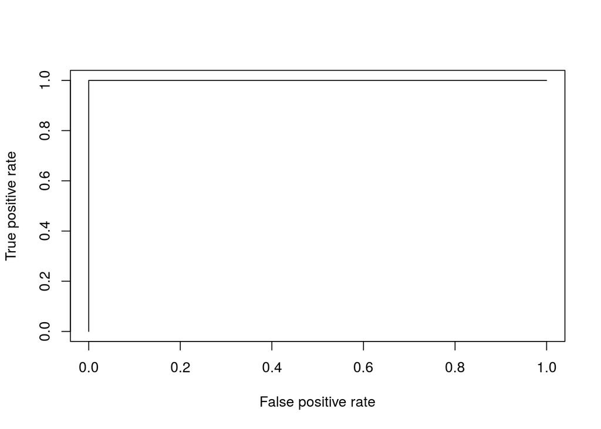

```r
plot(roc(m2, d2))
```

Notre classification est parfait, c’est à dire que le point (0,1) est atteint, cela s’explique par ce qu’on a vu précédemment, c’est à dire qu’il n’y a pas de corrélation entre les variables explicatives et la variable à expliquer, on peut parler du surapprentissage de notre modèle

# Ajustement d’une régression logistique sur le jeu de données augmenté

Le but de cette partie est d’éviter le surapprentissage de notre modèle, pour cela nous devons avoir plus d’individus pour établir notre modèle, on va donc au lieu d’enlever les individus ayant des valeurs manquantes `NA` essayer de prédire ces valeurs manquantes

Rappel du nombre de valeurs manquantes par variables :

```r
colSums(is.na(d))
```

```
##           class             age             sex         steriod      antivirals
##               0               0               0               1               0
##         fatigue         malaise        anorexia       liver_big      liver_firm
##               1               1               1              10              11
## spleen_palpable         spiders          asites         varices       bilirubin
##               5               5               5               5               6
##   alk_phosphate            sgot         albumin         protime       histology
##              29               4              16              67               0
```

## Modèle de prédiction de la variable `protime`

On va prédire la variable `protime` avec une régression linéaire en utilisant la même méthode que pour la variable `class` :

```r
m3 <- lm(formula = protime~., data = d2)
m4 <- step(m3)
```

On obtient donc le modèle suivant :

```r
summary(m4)
```

```
##
## Call:
## lm(formula = protime ~ class + antivirals + spiders + bilirubin +
##     albumin, data = d2)
##
## Residuals:
##     Min      1Q  Median      3Q     Max
## -78.393 -10.777  -1.807  11.897  37.767
##
## Coefficients:
##               Estimate Std. Error t value Pr(>|t|)
## (Intercept)      1.307     18.965   0.069   0.9452
## classlive        9.902      7.158   1.383   0.1707
## antiviralsyes    9.292      5.346   1.738   0.0864 .
## spidersyes       9.655      5.270   1.832   0.0710 .
## bilirubin       -4.851      2.890  -1.678   0.0975 .
## albumin         11.797      4.650   2.537   0.0133 *
## ---
## Signif. codes:  0 '***' 0.001 '**' 0.01 '*' 0.05 '.' 0.1 ' ' 1
##
## Residual standard error: 19.97 on 74 degrees of freedom
## Multiple R-squared:  0.3193, Adjusted R-squared:  0.2733
## F-statistic: 6.943 on 5 and 74 DF,  p-value: 2.298e-05
```

## Estimation de la variable `protime`

Maintenant que nous avons construit le modèle de prédiction, nous allons estimer les différentes valeurs de cette variable :

```r
estimation <- predict(m4, d)
print(estimation)
```

```
##          1          2          3          4          5          6          7
##  72.494306  67.080761  73.949461  64.657954  72.494306  72.979358         NA
##          8          9         10         11         12         13         14
##         NA  78.668338  71.314587  66.466521  50.008723  62.508131  77.291161
##         15         16         17         18         19         20         21
##         NA  54.666877  75.063361  74.434512  75.129180  67.017392  66.047289
##         22         23         24         25         26         27         28
##  63.049004  72.494306  81.237393  69.652266  71.104970  51.948929  45.562830
##         29         30         31         32         33         34         35
##  68.679712  70.281115  44.635318         NA  76.455147  72.560125  76.518516
##         36         37         38         39         40         41         42
##  57.236662  72.218870  55.353998  72.494306  53.257837  64.657954         NA
##         43         44         45         46         47         48         49
##  77.213183  78.668338         NA  78.668338  62.420156  60.355858  75.823848
##         50         51         52         53         54         55         56
##  57.362474  72.979358  72.494306  79.153390  62.232696  76.308899         NA
##         57         58         59         60         61         62         63
##         NA  63.478234  66.741957         NA  79.848057  73.949461  43.634782
##         64         65         66         67         68         69         70
##  63.331987  67.565812  75.823848  62.152267  21.384346  72.494306  66.044838
##         71         72         73         74         75         76         77
##  77.003567         NA         NA  72.494306  85.405399  64.382518  39.828465
##         78         79         80         81         82         83         84
##  65.143005  67.558265  84.566935  82.902164  76.308899  73.949461         NA
##         85         86         87         88         89         90         91
##  60.204514  69.583996         NA  31.504611  37.810282  79.153390  56.246124
##         92         93         94         95         96         97         98
##  27.217124  72.494306  57.092135  45.792882  67.502444  62.629772  47.239759
##         99        100        101        102        103        104        105
##  50.445940         NA  19.168704         NA  53.906390  44.197811  36.781906
##        106        107        108        109        110        111        112
## 102.747777  33.995688         NA  58.483921  52.249896  76.308899  43.711329
##        113        114        115        116        117        118        119
##  72.494306  59.727009  63.751219         NA  73.674025  71.314587         NA
##        120        121        122        123        124        125        126
##  59.463732  43.721036  49.862475         NA  66.863598  62.839388  65.474262
##        127        128        129        130        131        132        133
##  62.839388  34.985496  60.906729  27.217124  78.392903   7.403374  55.629433
##        134        135        136        137        138        139        140
##  56.124483  63.142806  67.282830  69.708088  54.030482  36.420946  64.107083
##        141        142        143        144        145        146        147
##  44.107675  42.626841  51.042195  45.098214  29.696043  73.883641  30.337049
##        148        149        150        151        152        153        154
##         NA  72.979358  74.434512  12.665575  76.518516  64.989211  61.593849
##        155
##  41.349440
```

Et on peut maintenant remplacer les valeurs manquantes par nos estimations :

```r
d$protime[is.na(d$protime)] = estimation[is.na(d$protime)]
```

Et on créer un nouveau jeu de données avec nos estimations :

```r
d3 <- na.omit(d)
summary(d3)
```

```
##   class         age           sex     steriod  antivirals fatigue  malaise
##  die :19   Min.   : 7.0   female:13   no :54   no :22     no :73   no :42
##  live:93   1st Qu.:32.0   male  :99   yes:58   yes:90     yes:39   yes:70
##            Median :39.0
##            Mean   :41.2
##            3rd Qu.:50.0
##            Max.   :78.0
##  anorexia liver_big liver_firm spleen_palpable spiders  asites   varices
##  no :19   no :22    no :54     no :20          no :38   no :14   no :14
##  yes:93   yes:90    yes:58     yes:92          yes:74   yes:98   yes:98
##
##
##
##
##    bilirubin     alk_phosphate        sgot           albumin
##  Min.   :0.300   Min.   : 26.0   Min.   : 14.00   Min.   :2.100
##  1st Qu.:0.700   1st Qu.: 72.0   1st Qu.: 30.00   1st Qu.:3.500
##  Median :1.000   Median : 85.0   Median : 56.50   Median :4.000
##  Mean   :1.272   Mean   :105.5   Mean   : 78.62   Mean   :3.835
##  3rd Qu.:1.400   3rd Qu.:133.5   3rd Qu.: 98.00   3rd Qu.:4.200
##  Max.   :4.800   Max.   :295.0   Max.   :420.00   Max.   :5.300
##     protime       histology
##  Min.   :  0.00   no :65
##  1st Qu.: 46.75   yes:47
##  Median : 62.71
##  Mean   : 62.44
##  3rd Qu.: 75.30
##  Max.   :100.00
```

On décide de regarder si nous avons plus d’individus que notre jeu de données `d2` :

```r
dim(d3)
```

```
## [1] 112  20
```

## Nouveau modèle de prédiction de la variable `class`

Nous allons construire un nouveau modèle de prédiction de la variable `class` à partir de notre jeu de données `d3`, on va utiliser la même méthode que vu précédemment :

```r
m5 <- glm(formula = class~., data = d3, family = binomial(link = 'logit'))
m6 <- step(m5)
```

On obtient le modèle suivant :

```r
summary(m6)
```

```
##
## Call:
## glm(formula = class ~ sex + anorexia + spiders + asites + bilirubin +
##     protime, family = binomial(link = "logit"), data = d3)
##
## Deviance Residuals:
##     Min       1Q   Median       3Q      Max
## -3.2106   0.0001   0.1757   0.3383   1.7369
##
## Coefficients:
##               Estimate Std. Error z value Pr(>|z|)
## (Intercept)   17.01397 2473.77703   0.007   0.9945
## sexmale      -18.05106 2473.77665  -0.007   0.9942
## anorexiayes   -2.55273    1.09869  -2.323   0.0202 *
## spidersyes     1.97717    0.78093   2.532   0.0113 *
## asitesyes      2.02069    0.84777   2.384   0.0171 *
## bilirubin     -0.64078    0.41220  -1.555   0.1201
## protime        0.05552    0.02076   2.674   0.0075 **
## ---
## Signif. codes:  0 '***' 0.001 '**' 0.01 '*' 0.05 '.' 0.1 ' ' 1
##
## (Dispersion parameter for binomial family taken to be 1)
##
##     Null deviance: 101.992  on 111  degrees of freedom
## Residual deviance:  52.083  on 105  degrees of freedom
## AIC: 66.083
##
## Number of Fisher Scoring iterations: 18
```

On va maintenant vérifier les perfomances de notre nouveau modèle :

```r
mat_conf <- table(
  factor(ifelse(
    predict(m6, d3[-1]) > 0.5,
    1,
    0)),
  d3$class)

paste('Se (Sensibilité) =', se(mat_conf))
```

```
## [1] "Se (Sensibilité) = 0.945652173913043"
```

```r
paste('Sp (Spécificité) =', sp(mat_conf))
```

```
## [1] "Sp (Spécificité) = 0.7"
```

```r
paste('TBC (Taux Bien Classé) =', tbc(mat_conf))
```

```
## [1] "TBC (Taux Bien Classé) = 0.901785714285714"
```

On obtient des valeurs qui sont plus cohérentes que précédemment, les indicateurs ne sont plus parfaits mais restent performants, Et on décided’afficher la courbe ROC associée :

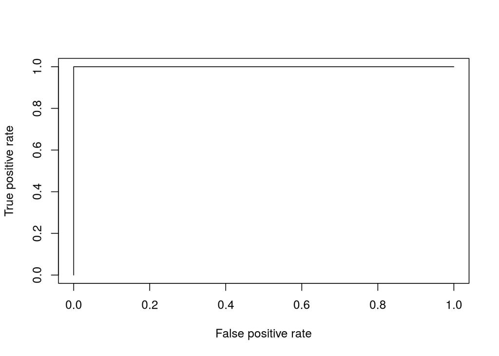

```r
plot(roc(m6, d3))
```

On obtient toujours une courbe ROC parfaite, or cela ne semble pas cohérent étant donné que nos indicateurs Se, Sp et TBC ne sont plus parfaits